# Final Project Phase 3

## Team Information

- Apple vs. Spotify - A Social Media Rivalrly Analysis
- Alex Bzdel - abzdel@bryant.edu
- Zach Galante - zgalante@bryant.edu
- Robert Mitchell - rmitchell2@bryant.edu
- Group 2: Pied Piper

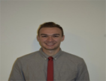

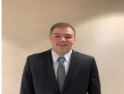

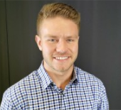

# Abstract

We plan to explore an artist’s popularity on Spotify’s streaming platform in comparison to Apple’s. We will first use the number of tweets about an artist to determine how many people are talking about them. Then we will pass that information into our equation (explained in detail in a further section) to get a rating for each tweet, which we can then see by each artist as well. In conclusion we will then make our own top 10 artists list based off of the data from both Apple Music and Spotify. This will then give us insights to our hypothesis to see which platform exposure through social media has a greater impact on. We will not be factoring in the sentiments of the tweets as we are simply testing whether being talked about more equates to having a higher rating on the Spotify and Apple top artists. This is due to the fact that, even if a user is Tweeting negatively about an artist, the Tweet will be seen by people who will stream their songs as a result of seeing the negative Tweet, to see how bad it is (for a fun way of understanding this click [here](https://youtu.be/BD5ha9mENzw)). This would still counts the same as if someone was listening to the song because they heard how good it is. In terms of ranking tweets by importance, we will use a variety of factors. We plan to use the number of favorites and the number of followers that each follower has, in addition to the rank based on the number of tweets.

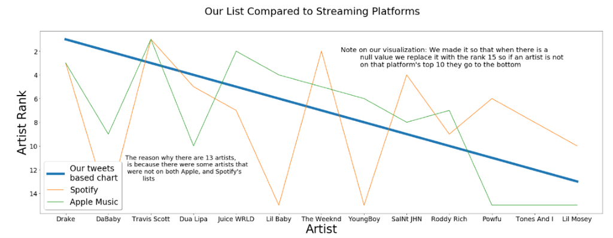

## Hypothesis

A higher quantity of tweets about an artist directly leads to a higher placement on the top charts. With our tweet rating metric we will ensure that, despite having a high quantity of tweets about an artist, poor tweets will be filtered out

[figure not shown]

```python
#install twython
!pip install twython
```

# Description of the data

## Scraper(s) used

```python
from twython import TwythonStreamer
import csv
import json
import codecs
import time
from random import seed
from random import randint
# seed random number generator
seed(1)

tweets_filename = "twitter_output_Spotify10"

consumer_key = "ND4wRUZRSgRS1NBtb9vRbm96v"
consumer_secret = "z0zxb6QObq4AUU2bA8BBclnIZbDr89vShniSZ9NjMWHUaIJ2AK"
access_token = "1250793114274598913-1mA5LzmdeGsu7PvTD1QpoZymfUPrPl"
access_token_secret = "cqNiCEcr5OsbS5G1t3uAGhZhqabgeu7XVHZluQiJIBVnf"

tweetabbr = []

# In this session we are using the Twitter IDs to gather tweets from those accounts.
AllPDs = ['561106229', '34296669', '974277346252423169', '121222566', '991525350', '378424739',
          '35871927', '304847225']
# Filter out unwanted data for the CSV file. We are saving the entire JSON to a seperate file should we need more data.
def process_tweet(tweet):
    d = {}
    d['hashtags'] = [hashtag['text'] for hashtag in tweet['entities']['hashtags']]
    d['id'] = tweet['id']
    d['text'] = tweet['text']
    d['name'] = tweet['user']['name']
    d['user'] = tweet['user']['screen_name']
    d['user_loc'] = tweet['user']['location']
    d['user_desc'] = tweet['user']['description']
    d['user_followers'] = tweet['user']['followers_count']
    d['user_friends'] = tweet['user']['friends_count']
    d['user_listed'] = tweet['user']['listed_count']
    d['user_created'] = tweet['user']['created_at']
    d['user_favs'] = tweet['user']['favourites_count']
    d['user_statuses'] = tweet['user']['statuses_count']

    return d


# Create a class that inherits TwythonStreamer
class MyStreamer(TwythonStreamer):

    # Received data
    def on_success(self, data):

        # Save full JSON to file
        # TODO : save properly so we can load later directly
        # A tweet JSON record per line
        with open(f'{tweets_filename}.json', 'a') as jsonfile:
            json.dump(data, jsonfile)
            jsonfile.write("\n")

        # Only save tweets in English
        if data['lang'] == 'en':
            tweet_data = process_tweet(data)
            self.save_to_csv(tweet_data)

    # Problem with the API
    def on_error(self, status_code, data):
        print(status_code, data)
        self.disconnect()

    # Save each tweet to csv file
    def save_to_csv(self, tweet):
        with open(f'{tweets_filename}.csv', 'a', encoding="utf8") as file:
            writer = csv.writer(file)
            writer.writerow(list(tweet.values()))

while True:
    try:
        # Instantiate from our streaming class
        stream = MyStreamer(consumer_key, consumer_secret,
                    access_token, access_token_secret)

        # Start the stream - this would capture tweets generated by specific accounts - ex. Harley Davidson's account
        # There are online tools to get the account number using the @ account name.
        # stream.statuses.filter(follow=17169239) #Track uses comma separated list

        # Start the stream - this would capture tweets generated by these accounts
        #stream.statuses.filter(follow=AllPDs) #Track uses comma separated list

        # Start the stream - This stream looks for specific terms (mentions)
        #stream.statuses.filter(track='@VASenate2018,@MariaCantwell,@Susan_Hutch,') #Track uses comma separated list
        stream.statuses.filter(track='Travis Scott, The Weekend, Drake, SAINt JHN, Dua Lipa, Powfu, Juice WRLD, Tones And I, Roddy Ricch, Lil Mosey')
        """
        the above tracks the Spotify top 10 artists - we used a separate scraper for Apple Music's
        the scraper for Apple Music looked like this:

        stream.statuses.filter(track='Travis Scott, Juice WRLD, Drake, Lil Baby, The Weekend, YoungBoy, Roddy Rich, SaINt JHN, DaBaby, Dua Lipa')
        """

    except (KeyboardInterrupt):
        print("Exiting")
        break
    except Exception as e:
        print("error - sleeping " + str(e))
        time.sleep(randint(30, 90)) #suspends (waits) execution of the current thread for a given number of seconds
        continue
```

```
Exiting
```

## Data description

- We scraped the following Tweet characteristics:
  - Hashtags
  - Tweet ID
  - Tweet text
  - User's display name
  - Username
  - User's location
  - User's description
  - Followers
  - Friends
  - Lists
  - Account creation date
  - Favorites
  - User total tweets
- We set the keywords to be the top 10 artists on both Spotify and Apple. There was a little bit of overlap, but some artists were unique to just one platform. We ended up with 13 artists total. ## When and how long you scraped Twitter
- We scraped Twitter on 4/24, 4/25, and 4/26 for 4-5 hours each day, we were able to scrape almost 100,000 tweets ## Alternative data source(s) used
- For alternative data sources, we used the Spotify and Apple Music Daily Top Charts for 4/24/2020. However, Spotify provided us with a csv file that included number of streams on that day while Apple Music only provided us with the top ranking songs.

## Load in Data

```python
import pandas as pd
import numpy as np
Spotify = pd.read_csv("twitter_output_Spotify10.csv")
Spotify.columns= ['Hashtags','ID','Tweet_Text','Name','Username','User_Location','User_Description','Followers','Friends','Lists','Account_Creation_Date','Favorites','User_Total_Tweets']
Apple  = pd.read_csv("twitter_output_Apple_Artists.csv")
Apple.columns= ['Hashtags','ID','Tweet_Text','Name','Username','User_Location','User_Description','Followers','Friends','Lists','Account_Creation_Date','Favorites','User_Total_Tweets']
df = Spotify.append(Apple, ignore_index =True)
df
```

|  | Hashtags | ID | Tweet_Text | Name | Username | User_Location | User_Description | Followers | Friends | Lists | Account_Creation_Date | Favorites | User_Total_Tweets |
| --- | --- | --- | --- | --- | --- | --- | --- | --- | --- | --- | --- | --- | --- |
| 0 | [] | 1.254237e+18 | RT @BelindaJones68: Coronavirus sure has highl... | Robyn Knobel | robyn_knobel | Australia | married 46 years ,love family ,friends ,social... | 235 | 310 | 13 | Mon Mar 25 16:59:38 +0000 2013 | 26063 | 42853 |
| 1 | [] | 1.254237e+18 | i understand everyone has an opinion, but what... | ekata lanrete ☄️💕🛸🚀 | a_akinfe | Morioh, Japan | 12 (and a half) years old 📸: Ig.ayo | 342 | 479 | 0 | Sat May 04 18:30:22 +0000 2019 | 16049 | 8098 |
| 2 | [] | 1.254237e+18 | Wow! We had some super fast times today in th... | RHS Girl’s Soccer | RHSGirlsSoccer5 | Rockville, MD | The Official Twitter account for the Rockville... | 112 | 22 | 0 | Fri Mar 22 13:26:40 +0000 2019 | 435 | 401 |
| 3 | [] | 1.254237e+18 | RT @tdiizzlleee: Two weeks man that’s all we h... | 𝚜𝚊𝚛𝚊 🍒 | ramencita | NaN | Today, smoking is going to save lives. 🇬🇹🇲🇽 . ... | 392 | 381 | 0 | Sat Feb 16 01:18:54 +0000 2019 | 13839 | 11281 |
| 4 | [] | 1.254237e+18 | RT @DineshDSouza: Apparently the official prop... | QAnonPatriot 🇺🇸 🐇 | QAnonPatriot | Down The Rabbit Hole 🐇🕳️ | #WWG1WGA ⚔️\n#AmericaFirst 🇺🇲\n#DrainTheSwamp ... | 30450 | 130 | 108 | Fri Sep 30 04:43:45 +0000 2016 | 29480 | 35957 |
| ... | ... | ... | ... | ... | ... | ... | ... | ... | ... | ... | ... | ... | ... |
| 100060 | [] | 1.254560e+18 | I still can’t believe Juice Wrld is gone. \n\n... | Hannah 🧸 | hannah_banna24 | 🤷🏼‍♀️ Who tf knows | \|Instagram: hannahmlorenzen\| ~No matter where ... | 249 | 524 | 0 | Sun Jun 24 20:55:32 +0000 2018 | 10080 | 6358 |
| 100061 | ['TousEnsemble', 'StrongerTogether'] | 1.254560e+18 | ...Drake is still talking #TousEnsemble #Stron... | Erin Pepler | erinpepler | Toronto, Ontario | Writer, mom, consumer of overpriced coffee. By... | 1409 | 1883 | 54 | Tue May 13 17:54:33 +0000 2008 | 11911 | 6190 |
| 100062 | [] | 1.254560e+18 | RT @_DashawnJ_: JADED by Drake is a timeless s... | Lex ✨🌙 | justlexi95 | NaN | Dog mom to Kash ❤️ | 337 | 255 | 0 | Fri Nov 09 01:36:33 +0000 2012 | 25462 | 8296 |
| 100063 | [] | 1.254560e+18 | RT @calebturner_10: The amount of snap stories... | s o f | itssofiaosmani | Cali | 🇦🇫 | 465 | 297 | 2 | Sun May 31 20:11:36 +0000 2009 | 69134 | 31436 |
| 100064 | [] | 1.254560e+18 | Turns out I’ve been a fool for not listening t... | ✨🔮Crystal 🔮✨ | _Crystalosaurus | The Afterlife in Beetlejuice | Writer. Drinker of iced coffee. Petter of dogs... | 184 | 661 | 5 | Sat Jun 27 23:03:55 +0000 2009 | 18352 | 21005 |

100065 rows × 13 columns

## Drop Duplicates

```python
length  = len(df)
new_length = len(df.drop_duplicates())
print(f" The current length of our Dataframe is {length} records")
print(f" The length of our Dataframe after dropping duplicates is {new_length} records" )
```

```
 The current length of our Dataframe is 100065 records
 The length of our Dataframe after dropping duplicates is 99870 records
```

### Apple Music vs. Spotify Top 10 Artists

- We've created DataFrames for the top daily streamed songs on 4/24/2020 - one represents Spotify's top 10 and one represents Apple Music's
- We will be analyzing tweets about the artists associated with each song
- A more interesting analysis would include number of streams per song, but only Spotify provides this information to external users

### Loading top 10 lists

```python
# apple's top 10 artists as of 4/25
apple_top_10 = pd.read_csv('apple_top_10.csv')

# spotify top 10 artists as of 4/25
spotify_top_10 = pd.read_csv('spotify_top_10.csv')
```

```python
apple_top_10
```

|  | Track | Artist | Position |
| --- | --- | --- | --- |
| 0 | THE SCOTTS | Travis Scott | 1 |
| 1 | Righteous | Juice WRLD | 2 |
| 2 | Toosie Slide | Drake | 3 |
| 3 | Rockstar | Lil Baby | 4 |
| 4 | Blinding Lights | The Weeknd | 5 |
| 5 | Diamonds | YoungBoy Never Broke Again | 6 |
| 6 | The Box | Roddy Rich | 7 |
| 7 | Roses | SaINt JHN | 8 |
| 8 | JUMP | DaBaby | 9 |
| 9 | Don't Start Now | Dua Lipa | 10 |

```python
spotify_top_10=spotify_top_10.replace(to_replace="Roddy Ricch",value="Roddy Rich")
spotify_top_10=spotify_top_10.replace(to_replace="SAINt JHN",value="SaINt JHN") # fixing some incorrect spellings
spotify_top_10
```

|  | Track | Artist | Position |
| --- | --- | --- | --- |
| 0 | THE SCOTTS | Travis Scott | 1 |
| 1 | Blinding Lights | The Weeknd | 2 |
| 2 | Toosie Slide | Drake | 3 |
| 3 | Roses - Imanbek Remix | SaINt JHN | 4 |
| 4 | Don't Start Now | Dua Lipa | 5 |
| 5 | death bed (coffee for your head) (feat. beabad... | Powfu | 6 |
| 6 | Righteous | Juice WRLD | 7 |
| 7 | Dance Monkey | Tones And I | 8 |
| 8 | The Box | Roddy Rich | 9 |
| 9 | Blueberry Faygo | Lil Mosey | 10 |

Now, we'll create one combined DataFrame, showing Apple Music's Top 10 vs Spotify's

```python
all_rankings = apple_top_10.rename(columns={'Track': 'Track: Apple', 'Artist': 'Artist: Apple', 'Position': 'Position: Apple'})
all_rankings = pd.merge(all_rankings, spotify_top_10, left_index=True, right_index=True)
all_rankings = all_rankings.rename(columns={'Track': 'Track: Spotify', 'Artist': 'Artist: Spotify', 'Position': 'Position: Spotify'})
all_rankings
```

|  | Track: Apple | Artist: Apple | Position: Apple | Track: Spotify | Artist: Spotify | Position: Spotify |
| --- | --- | --- | --- | --- | --- | --- |
| 0 | THE SCOTTS | Travis Scott | 1 | THE SCOTTS | Travis Scott | 1 |
| 1 | Righteous | Juice WRLD | 2 | Blinding Lights | The Weeknd | 2 |
| 2 | Toosie Slide | Drake | 3 | Toosie Slide | Drake | 3 |
| 3 | Rockstar | Lil Baby | 4 | Roses - Imanbek Remix | SaINt JHN | 4 |
| 4 | Blinding Lights | The Weeknd | 5 | Don't Start Now | Dua Lipa | 5 |
| 5 | Diamonds | YoungBoy Never Broke Again | 6 | death bed (coffee for your head) (feat. beabad... | Powfu | 6 |
| 6 | The Box | Roddy Rich | 7 | Righteous | Juice WRLD | 7 |
| 7 | Roses | SaINt JHN | 8 | Dance Monkey | Tones And I | 8 |
| 8 | JUMP | DaBaby | 9 | The Box | Roddy Rich | 9 |
| 9 | Don't Start Now | Dua Lipa | 10 | Blueberry Faygo | Lil Mosey | 10 |